# Coursework Report

*N* removed NAs: 3

*N* removed typo: 1

*N* removed <18: 24

*N* total clean: 122

| Group | *N* | *M*<sub>age</sub> | *M*<sub>rating</sub> |
| --- | --- | --- | --- |
| Control | 57 | 20.53 | 5.18 |
| Experim | 65 | 20.60 | 5.94 |

**Main analysis results**

*t*(120) = -6.49, *p* < .001

[interactive chart not shown]

[figure not shown]

[interactive chart not shown]

# Coursework Report

Analysing Data, Spring 2020

# Methods

## Participants

Initially, a total of 150 participants (*M*<sub>age</sub> = 20.57, *SD*<sub>age</sub> = 1.93, range = 18 - 26) took part in this study. Data from 25 participants was removed due to unlikely values of age, and 3 participants were removed because they did not report their age. As a result, 122 participants were included in the analysis. Table 1 shows the number and age of participants in each experimental condition.

Table 1. *Descriptive statistics by colour condition*

| Condition | *N* | % | *M*<sub>age</sub> | *SD*<sub>age</sub> |
| --- | --- | --- | --- | --- |
| Control | 57 | 46.72 | 20.53 | 1.70 |
| Experimental | 65 | 53.28 | 20.60 | 2.13 |

## Design

This study was conducted as a replication of Elliot et al.’s (2010) work on whether attractiveness is influenced by colour, specifically Experiment 1. Following their model, participants were shown a picture of a moderately attractive young Caucasian man, with the colour of the background being either white (control condition) or red (experimental condition). The participants were then asked to answer three questions with a rating from 1 to 9. The questions were: “How attractive do you think this person is?”, “How pleasant is this person to look at?” and “If I were to meet the person in this picture face to face, I would think he is attractive”. A composite score of perceived attractiveness was obtained by averaging out the ratings from these three questions. Therefore, higher ratings would account for higher levels of attractiveness. An independent-measures *t*-test analysis was conducted, in order to test whether the mean ratings of the man’s attractiveness were influenced by the background colour.

# Results

In this study we evaluated whether the presence of the colour red would influence the ratings of mean attractiveness of a man’s photograph. Participants in the control group (white background) had a mean rating of attractiveness of 5.18 (SD = 0.69), and it was of 5.94 (SD = 0.6) in the experimental group (red background), as shown in Figure 1. The analysis showed the difference between the means of the two conditions was significant (*M*<sub>diff</sub> = -0.76, 95% CI [-0.99, -0.53], *t*(120) = -6.49, *p* < .001). These results indicate the colour red did have an effect on the participants’ perceived attractiveness of the man in the photograph.

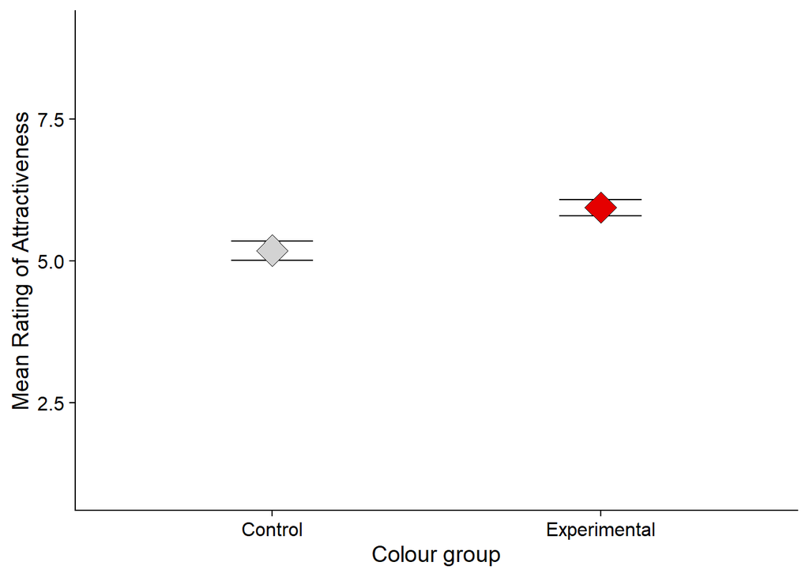

Figure 1. Mean ratings of perceived attractiveness by colour group

# Discussion

In this study we intended to replicate one of Elliot et al.’s (2010) experiments on red’s influence on perceived attractiveness. We presented a number of female participants a photograph of a man either on a red or white background, and measured their ratings of attractiveness. Our results indicate participants’ ratings were higher in the red condition. These results are in line with those of the original study, further supporting the reality of the red effect.

Research literature regarding human attraction includes a set of different factors that contribute to increasing men and women’s interest for the opposite sex. With this study we further contribute to establishing the colour red as one of those factors. However, research literature on the topic presents contradicting results. Peperkoorn, Roberts and Pollet (2016) carried out a similar study, in which they measured red’s effects on men’s attraction to women. Their results failed to support the colour-in-context theory, as participants did not present any significant preference for the women in the red condition in any of the three experiments they conducted. Hesslinger, Goldbach and Carbon (2015) also found that their results did not support the colour-in-context theory. The researchers conducted a total of two different experiments, with Experiment 1 being a close replication of Elliot et al.’s (2010) original study and Experiment 2 serving as an extended version of Experiment 1. In both of these experiments, the results indicated no statistically significant effect of the colour red, which contrasts with our findings.

Other studies in this field of research, however, have found the opposite results, in line with the ones from ours. Elliot, Tracy, Pazda and Beall (2013) conducted a study in Burkina Faso to test whether the red effect would also be present in a different cultural frame-work, than the ones it is most usually tested on. In their experiment, male participants were shown a picture of a woman with either a red or a blue border, and then were asked a few questions regarding their attraction to her. Research results showed the colour red did have an effect on men’s attraction to the woman. Red was found to be specifically related to romantic attraction, as the results did not show a strong influence in the more sexual-related questions, results which concur with those of prior research. Our own provides supporting evidence to this association, however, we did not explore the implications of a more sexual-oriented set of questions.  
When testing for colour-attractiveness associations, Roberts, Owen and Havlicek (2010) found that the colour red was associated with higher ratings of attractiveness across three out of three experiments they conducted. These results are in line with ours, thus further supporting the red effect. However, black also appeared to have the same influence, as the researchers did not find any significant differences between the ratings of the two colour conditions. Furthermore, the researchers found an apparent effect of the colour red on the wearer, which then in turn appeared to influence participants’ ratings.

These contrasting reports suggest the original red effect, although real, may not be the only way in which colour influences perceived attractiveness.

Moving forward, it would be of interest to increase the variability of the stimuli presented, such as having photographs of subjects of different levels of attractiveness or taking into account the styling of the subjects, in order to expand on the magnitude and reach of the colour red’s influence. It would also be recommendable to introduce different contexts in which to test participants’ ratings, so that in-group comparison or contrast effects, for example, could be taken into account and explored as well. Red’s possible indirect effects on human thinking should also be investigated further, as it has been shown its effects may not be limited to directly increasing the wearer’s attractiveness in the eyes of the observer but there are still no conclusive reports about it. Finally, to further study the relationship between the colour red and sexuality would also be of interest, in order to further consolidate the limits of the red effect: would it still influence asexual individuals, or individuals with no sexual or romantic interest in the subjects? These are questions that still need to be explored.

Overall, we can establish red does have an influence on human attraction, as it increases perceived attractiveness. Research literature on the topic shows, however, there is still no general agreement on the veracity of the red effect, and thus it should be investigated further, taking into account a broader range of factors that could also influence perceived attractiveness by interacting with the colour red.

# References

Elliot, A. J., Niesta Kayser, D., Greitemeyer, T., Lichtenfeld, S., Gramzow, R. H., Maier, M. A., & Liu, H. (2010). Red, rank, and romance in women viewing men. Journal of Experimental Psychology: General, 139(3), 399–417. https://doi.org/10.1037/a0019689

Elliot, A. J., Tracy, J. L., Pazda, A. D., & Beall, A. T. (2013). Red enhances women’s attractiveness to men: First evidence suggesting universality. Journal of Experimental Social Psychology, 49(1), 165–168. https://doi.org/10.1016/j.jesp.2012.07.017

Hesslinger, V. M., Goldbach, L., & Carbon, C.-C. (2015). Men in red: A reexamination of the red-attractiveness effect. Psychonomic Bulletin & Review, 22(4), 1142–1148. https://doi.org/10.3758/s13423-015-0866-8

Lehmann, G. K., Elliot, A. J., & Calin-Jageman, R. J. (2018). Meta-Analysis of the Effect of Red on Perceived Attractiveness. Evolutionary Psychology, 16(4), 147470491880241. https://doi.org/10.1177/1474704918802412

Peperkoorn, L. S., Roberts, S. C., & Pollet, T. V. (2016). Revisiting the Red Effect on Attractiveness and Sexual Receptivity: No Effect of the Color Red on Human Mate Preferences. Evolutionary Psychology, 14(4), 147470491667384. https://doi.org/10.1177/1474704916673841

Roberts, S. C., Owen, R. C., & Havlicek, J. (2010). Distinguishing between Perceiver and Wearer Effects in Clothing Color-Associated Attributions. Evolutionary Psychology, 8(3), 147470491000800. https://doi.org/10.1177/147470491000800304